# Homework 7

Frank Marino

March 22, 2026

> Canva and Tableau is not used for this assignment. There is also no presentation for this assignment.

## Set-up

> Homework 7 follows a tutorial for mapping spatio-temporal data using the `storms` data from the `dplyr` package. [Click here to access the full tutorial.](https://r-spatial.org/r/2017/08/28/nest.html)

### Load Libraries

```r
# Load any R Packages you may need
rm(list = ls())
library(mosaic)
library(tidyverse)
library(dplyr)
library(sf)
library(mapview)
```

### Load Data

```r
# Load Data
storms_data <- dplyr::storms
storms_data <- filter(storms_data, name == "Frances" | name == "Bret" | name == "Hortense")
storms_data <- filter(storms_data, status == "tropical depression" | status == "tropical storm" | status == "hurricane")
```

#### DO NOT EDIT THIS CODE CHUNK

## Exercise 1

### (a)

Create a base R plot that maps the tracks of the storms using longitude and latitude, while color coding by **storm status**.

```r
storms.sf <- storms_data %>%
    st_as_sf(coords = c("long", "lat"), crs = 4326)
class(storms.sf)
```

```
## [1] "sf"         "tbl_df"     "tbl"        "data.frame"
```

```r
storms.sf %>% select(name, year, geometry)
```

```
## Simple feature collection with 442 features and 2 fields
## Geometry type: POINT
## Dimension:     XY
## Bounding box:  xmin: -103 ymin: 9.2 xmax: -19 ymax: 51.2
## Geodetic CRS:  WGS 84
## # A tibble: 442 × 3
##    name     year     geometry
##    <chr>   <dbl>  <POINT [°]>
##  1 Frances  1976 (-37.5 12.5)
##  2 Frances  1976 (-45.3 14.7)
##  3 Frances  1976 (-49.6 16.6)
##  4 Frances  1976 (-50.5 17.5)
##  5 Frances  1976 (-51.6 18.3)
##  6 Frances  1976 (-54.2 20.2)
##  7 Frances  1976   (-54.9 21)
##  8 Frances  1976 (-55.2 23.1)
##  9 Frances  1976 (-54.9 25.3)
## 10 Frances  1976 (-54.3 26.3)
## # ℹ 432 more rows
```

```r
storms.sf <- storms.sf %>%
    mutate(time = as.POSIXct(paste(paste(year,month,day, sep = "-"),
                                   paste(hour, ":00", sep = "")))) %>%
    select(-month, -day, -hour)
storms.sf %>% select(name, time, geometry)
```

```
## Simple feature collection with 442 features and 2 fields
## Geometry type: POINT
## Dimension:     XY
## Bounding box:  xmin: -103 ymin: 9.2 xmax: -19 ymax: 51.2
## Geodetic CRS:  WGS 84
## # A tibble: 442 × 3
##    name    time                    geometry
##    <chr>   <dttm>               <POINT [°]>
##  1 Frances 1976-08-27 12:00:00 (-37.5 12.5)
##  2 Frances 1976-08-28 18:00:00 (-45.3 14.7)
##  3 Frances 1976-08-29 12:00:00 (-49.6 16.6)
##  4 Frances 1976-08-29 18:00:00 (-50.5 17.5)
##  5 Frances 1976-08-30 00:00:00 (-51.6 18.3)
##  6 Frances 1976-08-30 18:00:00 (-54.2 20.2)
##  7 Frances 1976-08-31 00:00:00   (-54.9 21)
##  8 Frances 1976-08-31 12:00:00 (-55.2 23.1)
##  9 Frances 1976-09-01 00:00:00 (-54.9 25.3)
## 10 Frances 1976-09-01 06:00:00 (-54.3 26.3)
## # ℹ 432 more rows
```

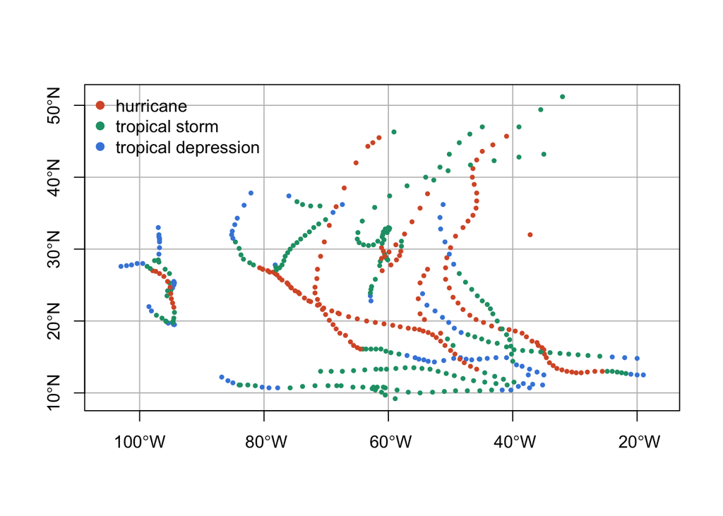

```r
status_colors <- c(
  "hurricane"           = "#D85A30",
  "tropical storm"      = "#1D9E75",
  "tropical depression" = "#4488DD"
)

# Map each point's status to the correct color
point_colors <- status_colors[as.character(storms.sf$status)]

plot(st_geometry(storms.sf),
     cex     = .5,
     pch     = 19,
     axes    = TRUE,
     graticule = TRUE,
     col     = point_colors)

legend("topleft",
       legend = names(status_colors),
       col    = status_colors,
       pch    = 19,
       bty    = "n")
```

### (b)

Create a plot using `ggplot()` that maps the tracks of the storms using longitude and latitude, while color coding by **storm name**.

```r
(storms.nest <- storms.sf %>% group_by(name, year) %>% nest)
```

```
## # A tibble: 17 × 3
## # Groups:   name, year [17]
##    name      year data
##    <chr>    <dbl> <list>
##  1 Frances   1976 <sf [12 × 8]>
##  2 Frances   1980 <sf [60 × 8]>
##  3 Bret      1981 <sf [5 × 8]>
##  4 Hortense  1984 <sf [33 × 8]>
##  5 Frances   1986 <sf [13 × 8]>
##  6 Bret      1987 <sf [26 × 8]>
##  7 Hortense  1990 <sf [26 × 8]>
##  8 Frances   1992 <sf [16 × 8]>
##  9 Bret      1993 <sf [33 × 8]>
## 10 Hortense  1996 <sf [50 × 8]>
## 11 Frances   1998 <sf [21 × 8]>
## 12 Bret      1999 <sf [26 × 8]>
## 13 Frances   2004 <sf [67 × 8]>
## 14 Bret      2005 <sf [7 × 8]>
## 15 Bret      2011 <sf [19 × 8]>
## 16 Bret      2017 <sf [5 × 8]>
## 17 Bret      2023 <sf [23 × 8]>
```

```r
to_line <- function(tr) st_cast(st_combine(tr), "LINESTRING") %>% .[[1]]
(tracks <- storms.nest %>% pull(data) %>% map(to_line) %>% st_sfc(crs = 4326))
```

```
## Geometry set for 17 features
## Geometry type: LINESTRING
## Dimension:     XY
## Bounding box:  xmin: -103 ymin: 9.2 xmax: -19 ymax: 51.2
## Geodetic CRS:  WGS 84
## First 5 geometries:
```

```
## LINESTRING (-37.5 12.5, -45.3 14.7, -49.6 16.6,...
```

```
## LINESTRING (-19 12.5, -20 12.5, -21 12.6, -21.8...
```

```
## LINESTRING (-71 36, -72.5 36, -73.8 36.2, -74.7...
```

```
## LINESTRING (-60.1 28.5, -60.3 28.7, -60.4 28.9,...
```

```
## LINESTRING (-62.8 22.8, -62.9 23.5, -62.9 23.9,...
```

```r
(storms.tr <- storms.nest %>% select(-data) %>% st_sf(geometry = tracks))
```

```
## Simple feature collection with 17 features and 2 fields
## Geometry type: LINESTRING
## Dimension:     XY
## Bounding box:  xmin: -103 ymin: 9.2 xmax: -19 ymax: 51.2
## Geodetic CRS:  WGS 84
## # A tibble: 17 × 3
## # Groups:   name, year [17]
##    name      year                                                       geometry
##    <chr>    <dbl>                                               <LINESTRING [°]>
##  1 Frances   1976 (-37.5 12.5, -45.3 14.7, -49.6 16.6, -50.5 17.5, -51.6 18.3, …
##  2 Frances   1980 (-19 12.5, -20 12.5, -21 12.6, -21.8 12.7, -22.5 12.8, -23.2 …
##  3 Bret      1981           (-71 36, -72.5 36, -73.8 36.2, -74.7 36.6, -76 37.4)
##  4 Hortense  1984 (-60.1 28.5, -60.3 28.7, -60.4 28.9, -60.6 29.3, -60.8 29.7, …
##  5 Frances   1986 (-62.8 22.8, -62.9 23.5, -62.9 23.9, -62.8 24.4, -62.7 24.8, …
##  6 Bret      1987 (-20 14.8, -22 14.9, -24 15, -26 15.1, -27.9 15.2, -29.5 15.3…
##  7 Hortense  1990 (-35 12.5, -36.1 12.9, -37.3 13.3, -38.5 13.7, -39.4 13.9, -4…
##  8 Frances   1992 (-61.4 27.7, -61.3 28.3, -61.1 28.7, -60.6 29, -59.9 29.6, -5…
##  9 Bret      1993 (-40.3 10.4, -41.7 10.4, -43.4 10.4, -45.3 10.3, -47.3 10.3, …
## 10 Hortense  1996 (-41 14.9, -42.7 14.9, -44.1 14.8, -45.4 14.7, -46.6 14.6, -4…
## 11 Frances   1998 (-94.5 25.5, -94.4 25.3, -94.5 25, -94.7 24.6, -95.5 24.2, -9…
## 12 Bret      1999 (-94.4 19.5, -94.5 19.5, -94.6 19.6, -94.6 19.7, -94.7 19.8, …
## 13 Frances   2004 (-35.2 11.1, -36.8 11.2, -38.3 11.3, -39.8 11.5, -41.5 11.9, …
## 14 Bret      2005 (-95.4 19.7, -95.7 19.9, -95.8 20, -96.4 20.4, -97.3 20.8, -9…
## 15 Bret      2011 (-78.2 27.8, -78.1 27.5, -78 27.1, -77.5 27.4, -77.1 27.8, -7…
## 16 Bret      2017     (-58.9 9.2, -60.5 9.7, -61.1 10.1, -62.1 10.4, -62.6 10.6)
## 17 Bret      2023 (-37.3 10.7, -39.1 10.9, -40.9 11.1, -42.7 11.3, -44.5 11.5, …
```

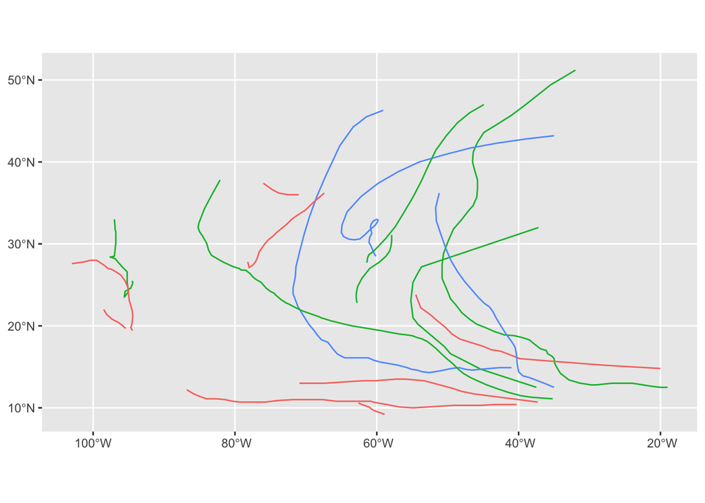

```r
storms.tr %>%
    ggplot(aes(color = name)) + geom_sf() + theme(legend.position="none")
```

### (c)

Create a plot using `ggplot()` that maps the tracks of the storms using longitude and latitude, while color coding by **year**.

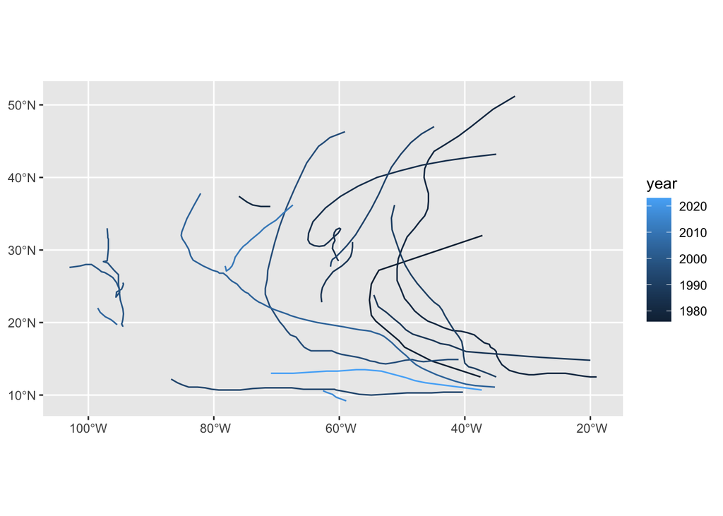

```r
storms.tr %>% ggplot(aes(color = year)) + geom_sf()
```

### (d)

Create a plot using `mapview()` that maps the tracks of the storms, while color coding by **year**.

```r
library(mapview)
mapview(storms.tr, zcol = "year", legend = TRUE)
```

[interactive chart not shown]

## Exercise 2

### (a)

Create a plot using `ggplot()` that maps the tracks of the storms using longitude and latitude, while color coding by **wind**.

```r
to_lines <- function(tr) {
    g = st_geometry(tr)
    hd = head(g, -1)
    tl = tail(g, -1)
    map2(hd, tl, function(x,y) st_combine(st_sfc(x, y, crs = 4326))) %>%
        map(function(x) st_cast(x, "LINESTRING"))
}
trs <- storms.nest %>%
    pull(data) %>%
    map(to_lines) %>%
    unlist(recursive = FALSE) %>%
    do.call(c, .)
fn = function(x) head(x, -1) %>% as.data.frame %>% select(-geometry)
storms.nest <- storms.nest %>% mutate(data = map(data, fn))
storms.tr2 <- storms.nest %>% unnest %>% st_set_geometry(trs)
nrow(storms.tr2)
```

```
## [1] 425
```

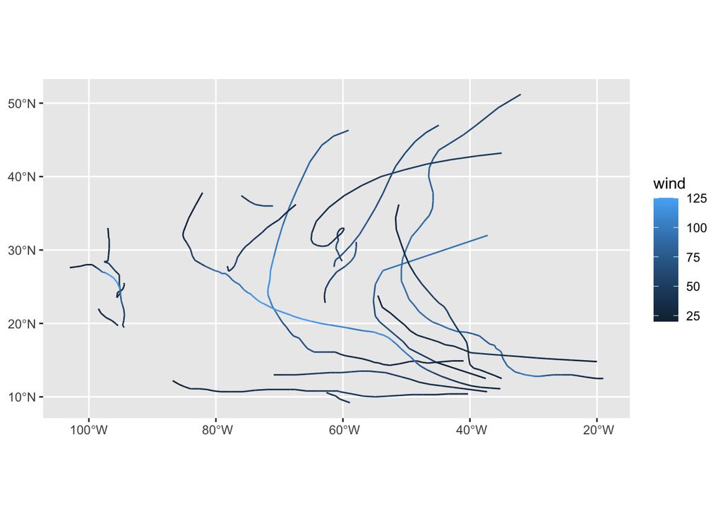

```r
## [1] 9584
storms.tr2 %>% ggplot(aes(color = wind)) + geom_sf()
```

### (b)

Create a plot that maps the tracks of the storms using `mapview()`, while color coding by **wind**.

```r
mapview(storms.tr2, zcol = "wind", legend = TRUE)
```

[interactive chart not shown]

## Exercise 3

### (a)

Now create a new subset to filter on the data to have time greater than January 1, 2010.

```r
storms.tr3 <- storms.tr2 %>%
    filter(time >= as.POSIXct("2010-01-01"))
mapview(storms.tr3, zcol = "wind", lwd = 4)
```

[interactive chart not shown]

### (b)

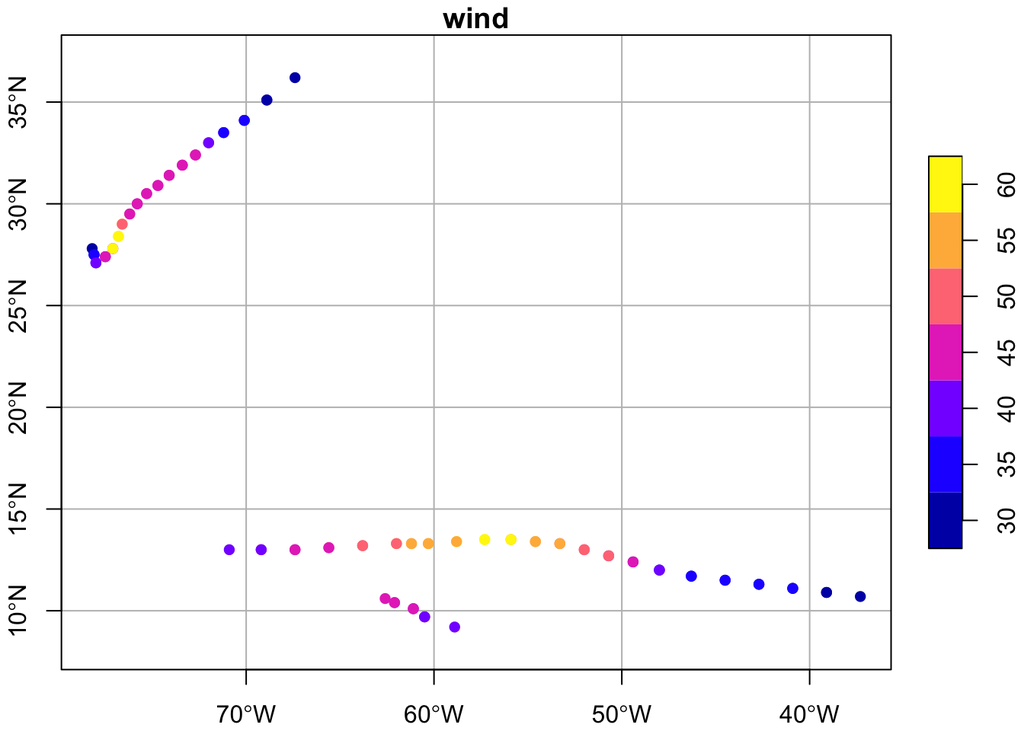

```r
plot(storms.tr3["wind"], type = 'p', cex = .2, pch = 16, axes = TRUE,
     graticule = TRUE)
plot(storms.tr3["wind"], type = 'l', add = TRUE)
```

### (c)

Create a plot using `mapview()` that maps the tracks of the storms using, while color coding by **wind**.

```r
mapview(storms.tr3, zcol = "wind", lwd = 4, legend = TRUE) +
  mapview(st_cast(storms.tr3, "POINT"), zcol = "wind", cex = 4)
```

[interactive chart not shown]

## All done!

Knit the completed R Markdown file as a HTML document (click the “Knit” button at the top of the script editor window) and upload it to the submission portal on Canvas.